# Adam Zeilinger ZIB model (v.3) Month Fixed

Daniel Turek

## Updates (v.3)

- Changed the month covariate into a factor, that is, a fixed value 1, 2, 3, …, 12 corresponding to each month, instead of a standardized continuous variable as before.
- Part I: Used this month factor as a fixed effect in the model, and removed the old month variables: month, quadratic month, and interactions between month and year
- Part II: Added a second model, *without* the monthly fixed effets, since none of them had any significant effect.
- Also included 90% credible intervals for the second model (Part II), since several of the `beta[i]` become significant at the 90% level.

## Updates (v.2)

- Using new data set with N = 958 observations (lists >= 4 species)
- Removed quadratic year^2 effect, and added year:month and year:month^2 interactions to occpancy process
- Transformed new siteID (raster cell numbers) into sequential indexing of random effects
- Changed the prior for sigma_alpha form uniform(0, 500) to uniform(0, 1000), to capture more of the long right-tail of the posterior.

## Preliminaries

This time, we’ll jump straight to the most efficient MCMCs.

There are two parts. Part I considers the use of fixed effects for each month, and Part II drops these fixed effects.

```r
require(nimble)
require(rjags)
require(coda)

## this is the new data set, with month as a factor: 1, 2, 3, ..., 12
load('../data/zib_data_v4_monthfixed.RData')

source('definitions.R')

fromR <- TRUE
```

## Part I: Month as fixed effects

Same as before, except month will be a fixed effect.

```r
code <- nimbleCode({
    mu_alpha ~ dnorm(0, 0.001)
    sigma_alpha ~ dunif(0, 1000)
    for(j in 1:nsite) {
        alpha[j] ~ dnorm(mu_alpha, sd = sigma_alpha)  ## site random effect
    }
    for(i in 1:7) {
        beta[i] ~ dnorm(0, 0.001)
    }
    for(i in 1:12) {
        betamonth[i] ~ dnorm(0, 0.001)    ## new fixed effects for each month
    }
    for(i in 1:N) {
        logit(p_occ[i]) <- alpha[siteID[i]] + beta[4]*aet[i] + beta[5]*tmn[i] + beta[6]*tmx[i] + beta[7]*year[i] + betamonth[monthfixed[i]]
        logit(p_obs[i]) <- beta[1] + beta[2]*list_length[i] + beta[3]*year_list_length[i]
        y[i] ~ dOccupancy(p_occ[i], p_obs[i])
    }
})

constants <- list(N=N, nsite=nsite, aet=aet, tmn=tmn, tmx=tmx, year=year, monthfixed=monthfixed, list_length=list_length, year_list_length=year_list_length, siteID=siteID)

data <- list(y=y)

inits <- list(mu_alpha=0, sigma_alpha=1, alpha=rep(0,nsite), beta=rep(0,7), betamonth=rep(0,12))

modelInfo_monthfixed <- list(code=code, constants=constants, data=data, inits=inits, name='monthfixed')
```

## Part I: MCMC runs with month fixed effects

```r
Rmodel <- nimbleModel(modelInfo_monthfixed$code,
                      modelInfo_monthfixed$constants,
                      modelInfo_monthfixed$data,
                      modelInfo_monthfixed$inits)

Cmodel <- compileNimble(Rmodel)

spec <- configureMCMC(Rmodel)

## configure this specification the same as log_shft_blk as before
spec$removeSamplers('beta[1:7]')
spec$addSampler('beta[1:3]', 'RW_block')
spec$addSampler('beta[4:7]', 'RW_block')
spec$removeSamplers('sigma_alpha')
spec$addSampler('sigma_alpha', 'RW_log_shift', list(shiftNodes='alpha'))

Rmcmc <- buildMCMC(spec)
Cmcmc <- compileNimble(Rmcmc, project = Rmodel)
```

Now we’ll run two chains of this MCMC algorithm, each with 500,000 MCMC iterations.

We’ll manually remove the first 100,000 samples as burnin.

```r
niter <- 500000

set.seed(1)
Cmcmc$run(niter)
samples1 <- as.matrix(Cmcmc$mvSamples)[100001:niter, ]

set.seed(2)
Cmcmc$run(niter)
samples2 <- as.matrix(Cmcmc$mvSamples)[100001:niter, ]

mcmc1 <- coda::as.mcmc(samples1)
mcmc2 <- coda::as.mcmc(samples2)
mcmcs <- coda::mcmc.list(mcmc1, mcmc2)

save(samples1, samples2, mcmcs, file = '../cached/final_MCMC_fixedmonth.RData')
```

## Part I: Assessing convergence

Now we assess convergence using these two MCMC chains.

We’ll use the mainstream Gelman & Rubin convergence diagnostic from the `coda` package. We want to see all values near to one.

```r
coda::gelman.diag(mcmcs, autoburnin = FALSE)
```

```
## Potential scale reduction factors:
##
##               Point est. Upper C.I.
## beta[1]                1       1.00
## beta[2]                1       1.00
## beta[3]                1       1.00
## beta[4]                1       1.00
## beta[5]                1       1.00
## beta[6]                1       1.00
## beta[7]                1       1.00
## betamonth[1]           1       1.00
## betamonth[2]           1       1.00
## betamonth[3]           1       1.00
## betamonth[4]           1       1.00
## betamonth[5]           1       1.00
## betamonth[6]           1       1.00
## betamonth[7]           1       1.00
## betamonth[8]           1       1.00
## betamonth[9]           1       1.00
## betamonth[10]          1       1.00
## betamonth[11]          1       1.00
## betamonth[12]          1       1.00
## mu_alpha               1       1.01
## sigma_alpha            1       1.00
##
## Multivariate psrf
##
## 1
```

Convergence looks excellent.

```r
apply(samples1, 2, coda::effectiveSize)
```

```
##       beta[1]       beta[2]       beta[3]       beta[4]       beta[5]
##      6132.150     28956.101     28775.006      4420.958      3458.436
##       beta[6]       beta[7]  betamonth[1]  betamonth[2]  betamonth[3]
##      3565.449      2504.718     89134.743     58433.579     17486.192
##  betamonth[4]  betamonth[5]  betamonth[6]  betamonth[7]  betamonth[8]
##     16034.859     14333.847     18308.535     22284.507     38560.251
##  betamonth[9] betamonth[10] betamonth[11] betamonth[12]      mu_alpha
##     20346.805     39300.451     34259.588     52816.808      4327.140
##   sigma_alpha
##      1497.778
```

## Part I: Posterior Inferences

### Part I: Posterior Mean

```r
cbind(apply(samples1, 2, mean),
      apply(samples2, 2, mean))
```

```
##                      [,1]        [,2]
## beta[1]        -2.4106659  -2.4194186
## beta[2]         0.2993353   0.2999053
## beta[3]         0.3348748   0.3335029
## beta[4]       -27.9394526 -26.9040271
## beta[5]       -14.8524612 -14.2524795
## beta[6]       -12.8591682 -13.5463556
## beta[7]        45.4363201  45.7333375
## betamonth[1]   -2.5678667  -2.7446083
## betamonth[2]    0.6481134   0.5907972
## betamonth[3]    3.0693340   2.5152838
## betamonth[4]    1.5186290   1.6132779
## betamonth[5]    0.3318077   0.2751007
## betamonth[6]  -23.2170010 -23.1854781
## betamonth[7]  -15.7873097 -15.7492775
## betamonth[8]   -3.2097430  -3.1527360
## betamonth[9]   16.4826521  16.2464619
## betamonth[10]  -1.0377767  -0.6792978
## betamonth[11]   5.3579697   5.1249765
## betamonth[12]   2.6695293   2.9728374
## mu_alpha      -17.8439790 -16.2958168
## sigma_alpha   200.8955665 205.1529575
```

### Part I: Posterior Median

```r
cbind(apply(samples1, 2, median),
      apply(samples2, 2, median))
```

```
##                      [,1]        [,2]
## beta[1]        -2.4162017  -2.4267115
## beta[2]         0.3025955   0.3028920
## beta[3]         0.3299997   0.3298757
## beta[4]       -28.4932362 -27.4521222
## beta[5]       -14.1814846 -13.8309960
## beta[6]       -13.2548928 -14.1687035
## beta[7]        43.7070882  43.9013393
## betamonth[1]   -2.5302260  -2.6619827
## betamonth[2]    0.7183451   0.6260988
## betamonth[3]    3.7225588   3.1377812
## betamonth[4]    1.6855133   1.8985242
## betamonth[5]    0.4246596   0.2758107
## betamonth[6]  -23.9465423 -23.7748127
## betamonth[7]  -16.1067808 -15.9364139
## betamonth[8]   -3.3355886  -3.0013937
## betamonth[9]   16.2422532  16.0623722
## betamonth[10]  -0.8325046  -0.5547293
## betamonth[11]   5.6616412   5.3477896
## betamonth[12]   2.5217410   2.7952001
## mu_alpha      -18.7207590 -17.1745010
## sigma_alpha   138.3750590 141.1070063
```

### Part I: 95% Credible Intervals

```r
cbind(apply(samples1, 2, function(x) quantile(x, 0.025)),
      apply(samples1, 2, function(x) quantile(x, 0.975)))
```

```
##                       [,1]        [,2]
## beta[1]        -2.89850169  -1.8867167
## beta[2]        -0.03208741   0.6177776
## beta[3]        -0.01691168   0.7139037
## beta[4]       -74.13875995  21.4313617
## beta[5]       -59.33028628  27.9204730
## beta[6]       -57.27332944  34.1728362
## beta[7]        14.22375006  86.1836593
## betamonth[1]  -64.15510501  59.0009838
## betamonth[2]  -59.75495515  60.8205824
## betamonth[3]  -57.63380316  59.6900461
## betamonth[4]  -55.03469275  56.6806611
## betamonth[5]  -54.85200776  55.2085598
## betamonth[6]  -82.61628603  39.9570243
## betamonth[7]  -75.11513998  45.1648193
## betamonth[8]  -61.53806444  54.7418816
## betamonth[9]  -36.63328245  70.8874158
## betamonth[10] -59.26086329  56.2905512
## betamonth[11] -53.35721319  62.6109068
## betamonth[12] -55.74891201  62.4825540
## mu_alpha      -69.71819355  40.1797695
## sigma_alpha    47.43889172 763.3162332
```

Note that *none* of the monthly fixed effects `betamonth` are significant. In fact, they’re fairly normally distributed around zero.

So we’ll simplify the model in Part II, and drop these monthly fixed effects.

## Part II: Without monthly fixed effects

Since none of the monthly fixed effects had any significant effect, we’ll remove them from the model and re-run. This saves us from fitting these 12 parameters, and should make all the other inferences more accurate.

Same as before, except without the month fixed effects.

```r
code <- nimbleCode({
    mu_alpha ~ dnorm(0, 0.001)
    sigma_alpha ~ dunif(0, 1000)
    for(j in 1:nsite) {
        alpha[j] ~ dnorm(mu_alpha, sd = sigma_alpha)  ## site random effect
    }
    for(i in 1:7) {
        beta[i] ~ dnorm(0, 0.001)
    }
    for(i in 1:N) {
        logit(p_occ[i]) <- alpha[siteID[i]] + beta[4]*aet[i] + beta[5]*tmn[i] + beta[6]*tmx[i] + beta[7]*year[i]
        logit(p_obs[i]) <- beta[1] + beta[2]*list_length[i] + beta[3]*year_list_length[i]
        y[i] ~ dOccupancy(p_occ[i], p_obs[i])
    }
})

constants <- list(N=N, nsite=nsite, aet=aet, tmn=tmn, tmx=tmx, year=year, list_length=list_length, year_list_length=year_list_length, siteID=siteID)

data <- list(y=y)

inits <- list(mu_alpha=0, sigma_alpha=1, alpha=rep(0,nsite), beta=rep(0,7))

modelInfo_nomonth <- list(code=code, constants=constants, data=data, inits=inits, name='nomonth')
```

## Part II: MCMC runs without month fixed effects

```r
Rmodel <- nimbleModel(modelInfo_nomonth$code,
                      modelInfo_nomonth$constants,
                      modelInfo_nomonth$data,
                      modelInfo_nomonth$inits)

Cmodel <- compileNimble(Rmodel)

spec <- configureMCMC(Rmodel)

## configure this specification the same as log_shft_blk as before
spec$removeSamplers('beta[1:7]')
spec$addSampler('beta[1:3]', 'RW_block')
spec$addSampler('beta[4:7]', 'RW_block')
spec$removeSamplers('sigma_alpha')
spec$addSampler('sigma_alpha', 'RW_log_shift', list(shiftNodes='alpha'))

Rmcmc <- buildMCMC(spec)
Cmcmc <- compileNimble(Rmcmc, project = Rmodel)
```

Now we’ll run two chains of this MCMC algorithm, each with 500,000 MCMC iterations.

We’ll manually remove the first 100,000 samples as burnin.

```r
niter <- 500000

set.seed(1)
Cmcmc$run(niter)
samples1 <- as.matrix(Cmcmc$mvSamples)[100001:niter, ]

set.seed(2)
Cmcmc$run(niter)
samples2 <- as.matrix(Cmcmc$mvSamples)[100001:niter, ]

mcmc1 <- coda::as.mcmc(samples1)
mcmc2 <- coda::as.mcmc(samples2)
mcmcs <- coda::mcmc.list(mcmc1, mcmc2)

save(samples1, samples2, mcmcs, file = '../cached/final_MCMC_nomonth.RData')
```

## Part II: Assessing convergence

Now we assess convergence using these two MCMC chains.

We’ll use the mainstream Gelman & Rubin convergence diagnostic from the `coda` package. We want to see all values near to one.

```r
coda::gelman.diag(mcmcs, autoburnin = FALSE)
```

```
## Potential scale reduction factors:
##
##             Point est. Upper C.I.
## beta[1]              1          1
## beta[2]              1          1
## beta[3]              1          1
## beta[4]              1          1
## beta[5]              1          1
## beta[6]              1          1
## beta[7]              1          1
## mu_alpha             1          1
## sigma_alpha          1          1
##
## Multivariate psrf
##
## 1
```

Convergence looks excellent.

```r
apply(samples1, 2, coda::effectiveSize)
```

```
##     beta[1]     beta[2]     beta[3]     beta[4]     beta[5]     beta[6]
##    7333.477   30016.998   29421.158    4900.311    3492.934    3374.315
##     beta[7]    mu_alpha sigma_alpha
##    2690.292    5042.561    1744.763
```

## Part II: Posterior Inferences

### Part II: Posterior Mean

```r
cbind(apply(samples1, 2, mean),
      apply(samples2, 2, mean))
```

```
##                    [,1]        [,2]
## beta[1]      -2.4477262  -2.4494297
## beta[2]       0.2979299   0.2987365
## beta[3]       0.3340442   0.3346144
## beta[4]     -27.0034064 -26.6180283
## beta[5]     -11.4461327 -12.3248694
## beta[6]     -12.7961108 -12.7275483
## beta[7]      44.3363996  44.7941478
## mu_alpha    -15.8292686 -16.0504172
## sigma_alpha 214.5682628 209.2007668
```

### Part II: Posterior Median

```r
cbind(apply(samples1, 2, median),
      apply(samples2, 2, median))
```

```
##                    [,1]        [,2]
## beta[1]      -2.4506155  -2.4500136
## beta[2]       0.3011569   0.3013878
## beta[3]       0.3290614   0.3302079
## beta[4]     -26.9648304 -26.5439537
## beta[5]     -10.3891408 -11.5611940
## beta[6]     -13.1132022 -13.2249009
## beta[7]      42.5045667  42.8227260
## mu_alpha    -16.9086529 -17.0801788
## sigma_alpha 145.4414383 144.1652452
```

### Part II: 95% Credible Intervals

```r
cbind(apply(samples1, 2, function(x) quantile(x, 0.025)),
      apply(samples1, 2, function(x) quantile(x, 0.975)))
```

```
##                     [,1]       [,2]
## beta[1]      -2.90911422  -1.976427
## beta[2]      -0.03222298   0.611633
## beta[3]      -0.01129332   0.705821
## beta[4]     -72.25349024  19.033683
## beta[5]     -59.25343081  32.184075
## beta[6]     -57.84085544  35.581080
## beta[7]      13.76519345  85.505113
## mu_alpha    -67.30908045  41.705438
## sigma_alpha  45.88732172 807.863180
```

### Part II: 90% Credible Intervals

I’m also including 90% credible intervals here, since both `beta[2]` and `beta[3]` are significant at the 90% level.

```r
cbind(apply(samples1, 2, function(x) quantile(x, 0.05)),
      apply(samples1, 2, function(x) quantile(x, 0.95)))
```

```
##                     [,1]        [,2]
## beta[1]      -2.83390535  -2.0515563
## beta[2]       0.02261358   0.5613593
## beta[3]       0.04207153   0.6427261
## beta[4]     -63.95003304  10.0362862
## beta[5]     -50.39431773  23.8231612
## beta[6]     -50.01007894  26.1818785
## beta[7]      17.36309287  77.9348152
## mu_alpha    -59.03055879  31.2485934
## sigma_alpha  54.15122902 663.6254643
```

### Part II: Posterior Density Plots

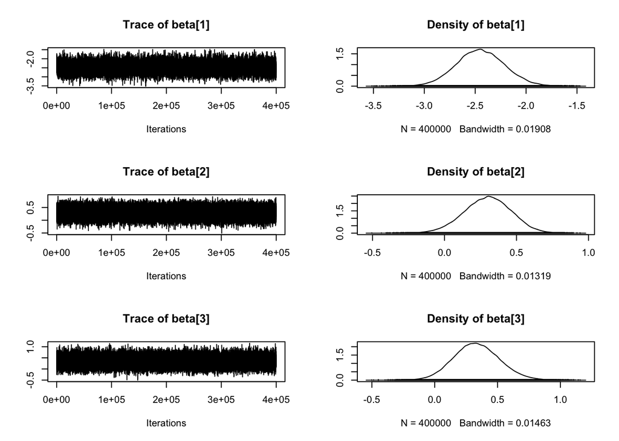

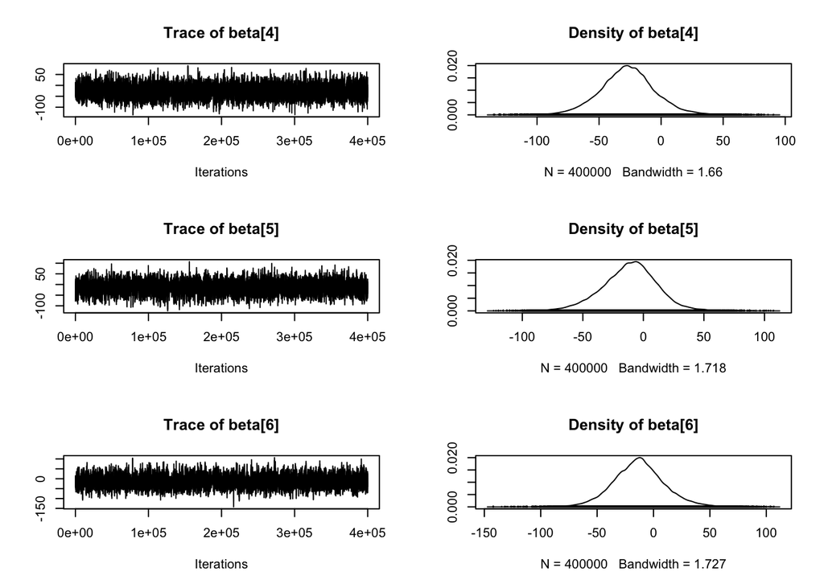

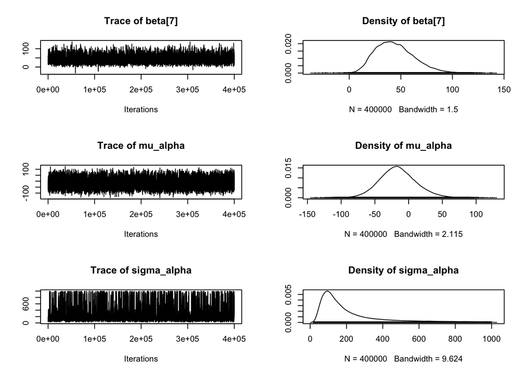

```r
plot(mcmcs[[1]], ask = FALSE)
```

## Wrap Up

I think this last version of the model (Part II) is our best yet. The handling of the month variable truly needed to be changed.

Also, now we see significant effects from a number of the variables, with some nice temporal trends as you had hoped.

Let me know when you’ve had a chance to look over this.

Cheers! - Daniel